# Self-Driving Car Engineer Nanodegree

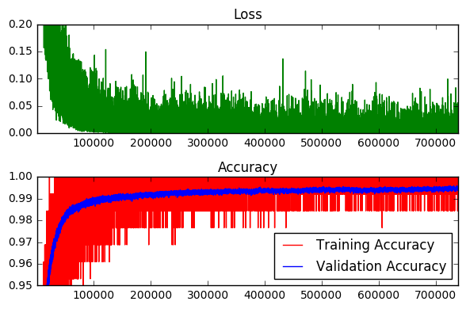

```
Validation accuracy at 0.9943022131919861
Test accuracy at 0.9698343276977539
```

```python
loss_plot = plt.subplot(211)
loss_plot.set_title('Loss')
loss_plot.plot(batches, loss_batch, 'g')
loss_plot.set_xlim([batches[0], batches[-1]])
loss_plot.set_ylim([0, 0.2])

acc_plot = plt.subplot(212)
acc_plot.set_title('Accuracy')
acc_plot.plot(batches, train_acc_batch, 'r', label='Training Accuracy')
acc_plot.plot(batches, valid_acc_batch, 'b', label='Validation Accuracy')
acc_plot.set_ylim([0.95, 1.0])
acc_plot.set_xlim([batches[0], batches[-1]])
acc_plot.legend(loc=4)
plt.tight_layout()
plt.show()

print('Validation accuracy at {}'.format(validation_accuracy))
print('Test accuracy at {}'.format(test_accuracy))
session.close()
```

### Question 4

*How did you train your model? (Type of optimizer, batch size, epochs, hyperparameters, etc.)*

**Answer:** The model was initially trained using stochastic gradient descent (SGD). Later SGD was swapped for the Adam Optimizer. No striking difference between the two optimizers was noticed during the initial training stages. The batch size was varied using just one epoch with the folloing batch size numbers (64,128,256). An acceptable compromise between speed and accuracy was found for a batch size of 128. Without regularization the architecture overfit quickly, but not too severly. Validation accuracy improved with the number of epochs increased monotonously for 1,100,500 and 1000 epochs. Presumably more training could still improve the results further. More exhaustive hyper parameter tuning would have been desirable, but was not feasible on a single GTX 1080 under the given time constraints.

Final result: the final test accuracy is 96.98% which is good but could certainly still be improved by more extensive hyper parameter tuning.

### Question 5

*What approach did you take in coming up with a solution to this problem?*

**Answer:** In order to reduce overfitting dropout regularization was implemented on the first fully connected layer. The keep probability was set to 0.5. This improved the test results and the validation and training accuracies no longer deviated very much. It can be seen in the graph above that training accuracy has a variance of about 1%. At the present stage training the model for 1000 epochs takes several hours and it is is not feasible to do exhaustive hyperparameter tuning. No other regularization procedures were implemented for this reason.

## Step 3: Test a Model on New Images

Take several pictures of traffic signs that you find on the web or around you (at least five), and run them through your classifier on your computer to produce example results. The classifier might not recognize some local signs but it could prove interesting nonetheless.

You may find `signnames.csv` useful as it contains mappings from the class id (integer) to the actual sign name.

### Implementation

Use the code cell (or multiple code cells, if necessary) to implement the first step of your project. Once you have completed your implementation and are satisfied with the results, be sure to thoroughly answer the questions that follow.

```
['13extra.jpg', '27extra.jpg', '25extra.jpg', '17extra.jpg', '15extra.jpg', '25bextra.jpg', '37extra.jpg', '33extra.jpg', '36extra.jpg', '39extra.jpg']
```

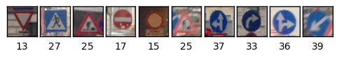

```python
### Load the images and plot them here.
### Feel free to use as many code cells as needed.

import glob
import cv2

extra_images = glob.glob('*extra.jpg')
print(extra_images)
n_imgs = len(extra_images)

shape=(n_imgs,32,32,3);
X_extra = np.zeros(shape,dtype='uint8')


def square_crop_image(image):
    n=min(image.shape[:2])
    crop = cv2.resize(image[:n,:n],(32,32), interpolation = cv2.INTER_CUBIC)
    return crop

# true class vector
y_extra = [int(y[:2]) for y in extra_images]

# generate the extra data set from the images taken
for img_name in extra_images:
    i = extra_images.index(img_name)
    img = plt.imread(img_name)
    img = square_crop_image(img)
    #plt.figure()
    #plt.imshow(img)
    X_extra[i]=img

plot_images(X_extra[:10],n_imgs=10, cls_true = y_extra[:10])
```

### Question 6

*Choose five candidate images of traffic signs and provide them in the report. Are there any particular qualities of the image(s) that might make classification difficult? It would be helpful to plot the images in the notebook.*

**Answer:** I took 10 pictures of traffic signs myself using a mobile phone, see above. The following shots are particularly interesting.

1. no vehicles sign at night time
2. no entry sign taken out the side window of a moving bus.
3. road road work sign, taken through the front window of a fast moving bus.
4. the Austrian variation of the pedestrians sign (not in the training set)
5. stay left sign taken from a moving bus.

Some are close ups, others from a distance of about 100 meters, most through the front window of a moving bus, but some also through the side windows which led to perspective distortions and greater motion blur. One was taken at night time. The traffic signs where manually extracted, interpolated and preprocessed like the training set to fit the (32,32,1) input shape of the neural network trained above. In the present case the distortions are due to motion blur, bad contrast and perspective distortions. Particularly interesting is the "pedestrians" sign shown below which does **not** occur in the training set in this form. The Austrian variation of this traffic sign differs significantly from the German one. I have nevertheless indicated the correct class, class 27, below.

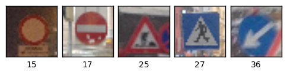

```python
import matplotlib.pyplot as plt
import matplotlib.image as mpimg

fig, axes = plt.subplots(1,5)
fig.subplots_adjust(hspace=0.2, wspace=0.1)
y_choose = np.array([15,17,25,27,36])
indices = [4,3,2,1,9]
X_choose  = X_extra[indices]

for i,ax in enumerate(axes.flat):
    xlabel = "{0}".format(y_choose[i])
    ax.set_xlabel(xlabel)
    ax.set_xticks([])
    ax.set_yticks([])
    ax.imshow(X_choose[i])
```

```python
### We predict the classes of all 10 extra images using the previously trained CNN
y_extra_cls = y_extra
y_choose_cls = y_choose
X_extra_pp  = preprocess_images(X_extra)
X_extra_pp  = X_extra_pp.astype(np.float32)
X_choose_pp = preprocess_images(X_choose)
X_choose_pp = X_choose_pp.astype(np.float32)

y_extra     = encoder.transform(y_extra_cls)
y_extra     = y_extra.astype(np.float32)
y_choose    = encoder.transform(y_choose_cls)
y_choose    = y_choose.astype(np.float32)
```

```python
# Here we go again!
session=tf.Session()
session.run(init)
saver.restore(session, './models/CNN_2layer_traffic_signs_01.ckpt')
```

```python
extra_accuracy = 0.0
extra_feed_dict  = {x_image: X_extra_pp, y_true: y_extra,keep_prob: 1.0}
extra_accuracy = session.run(accuracy, feed_dict=extra_feed_dict)
print('Extra data set accuracy at {}'.format(extra_accuracy))

choose_accuracy = 0.0
choose_feed_dict  = {x_image: X_choose_pp, y_true: y_choose,keep_prob: 1.0}
choose_accuracy = session.run(accuracy, feed_dict=choose_feed_dict)
print('Choose data set accuracy at {}'.format(choose_accuracy))
```

```
Extra data set accuracy at 0.8999999761581421
Choose data set accuracy at 0.6000000238418579
```

### Question 7

*Is your model able to perform equally well on captured pictures or a live camera stream when compared to testing on the dataset?*

```python
### Visualize the softmax probabilities here.
### Feel free to use as many code cells as needed.
#labels = tf.argmax(y_, 1)
#topFiver = tf.nn.in_top_k(y, labels, 5)
y_choose_predictions = session.run(tf.nn.top_k(y_pred,k=5), feed_dict=choose_feed_dict)
vals = y_choose_predictions.values
inds = y_choose_predictions.indices
```

```python
vals.round(2)
```

```
array([[ 1.        ,  0.        ,  0.        ,  0.        ,  0.        ],
       [ 0.97000003,  0.03      ,  0.        ,  0.        ,  0.        ],
       [ 1.        ,  0.        ,  0.        ,  0.        ,  0.        ],
       [ 0.85000002,  0.15000001,  0.        ,  0.        ,  0.        ],
       [ 1.        ,  0.        ,  0.        ,  0.        ,  0.        ]], dtype=float32)
```

```python
inds
```

```
array([[15,  8,  9,  7,  5],
       [17,  9, 14, 10, 38],
       [25, 11, 30, 20,  1],
       [18, 27, 26, 24, 25],
       [39, 20, 33, 25, 32]], dtype=int32)
```

Only two probabilities are significantly different from one. Together with the second highest probability they practically add up to one. We focus on these two cases and only on the two highest probabilities for this reason.

```
(-0.1, 1.1)
```

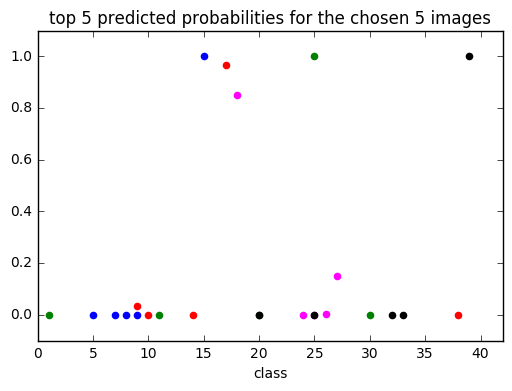

```python
y0,y1,y2,y3,y4 = vals[0,:],vals[1,:],vals[2,:],vals[3,:],vals[4,:]
x0,x1,x2,x3,x4=inds[0,:],inds[1,:],inds[2,:],inds[3,:],inds[4,:]
plt.scatter(x0,y0,color="blue")
plt.scatter(x1,y1,color="red")
plt.scatter(x2,y2,color="green")
plt.scatter(x3,y3,color="magenta")
plt.scatter(x4,y4,color="black")
plt.title('top 5 predicted probabilities for the chosen 5 images')
plt.xlabel('class')
plt.xlim([0,42])
plt.ylim([-0.1,1.1])
```

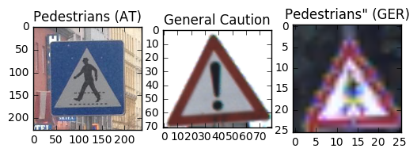

```python
pedestrians_AT =mpimg.imread('27extra.jpg')
pedestrians_GER =mpimg.imread('00001.ppm')
caution=mpimg.imread('00008.ppm')

fig = plt.figure()
a=fig.add_subplot(1,3,1)
plt.imshow(pedestrians_AT)
a.set_title('Pedestrians (AT)')
a=fig.add_subplot(1,3,3)
plt.imshow(pedestrians_GER)
a.set_title('Pedestrians" (GER)')
a=fig.add_subplot(1,3,2)
plt.imshow(caution)
a.set_title('General Caution')
```

It is now interesting to find out whether the "Pedestrians" sign generally gets confused for the "Caution" sign. To do this we check the accuracy on these two signs and the respective probability distributions.

```python
sign_class_accuracy = []
for sign_class in range(n_classes):
    _ = np.array(y_test_cls).astype(np.uint8)
    class_indices = np.where(_==sign_class)
    X_class = X_test[class_indices]
    y_class = y_test[class_indices]

    class_accuracy = 0.0
    class_feed_dict  = {x_image: X_class, y_true: y_class,keep_prob: 1.0}
    class_accuracy = session.run(accuracy, feed_dict=class_feed_dict)
    sign_class_accuracy.append([sign_class,class_accuracy])
    #sign_class_accuracy[sign_class] = class_accuracy
    #print('sign class accuracy at {}'.format(class_accuracy))
sign_class_accuracy = np.array(sign_class_accuracy)
```

```python
sign_class_accuracy[sign_class_accuracy[:,1]<0.90]
```

```
array([[  6.        ,   0.87333333],
       [ 18.        ,   0.89487189],
       [ 21.        ,   0.82222223],
       [ 26.        ,   0.84444451],
       [ 27.        ,   0.55000007],
       [ 30.        ,   0.75333333],
       [ 40.        ,   0.88888896]])
```

There are other traffic signs where the predictions are not accurate. The worst is the "Pedestrians" sign, class number 27, with an accuracy of only 55%, second is number 30 "Beware of ice, snow". Both occur rarely in the data set.

```
(-0.1, 1.1)
```

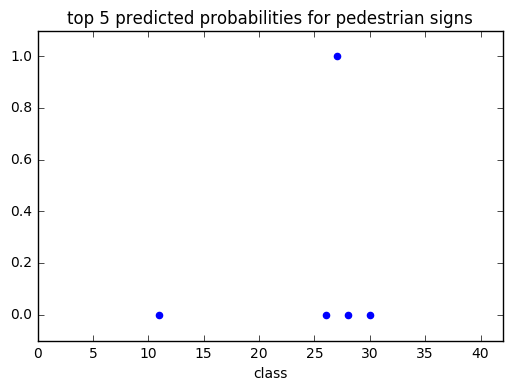

```python
_ = np.array(y_test_cls).astype(np.uint8)
class_indices = np.where(_==27)
X_pedestrian = X_test[class_indices]
y_pedestrian = y_test[class_indices]

pedestrian_accuracy = 0.0
pedestrian_feed_dict  = {x_image: X_pedestrian, y_true: y_pedestrian,keep_prob: 1.0}
y_pedestrians_pred = session.run(tf.nn.top_k(y_pred,k=5),
                         feed_dict=pedestrian_feed_dict)
vals = y_pedestrians_pred.values
inds = y_pedestrians_pred.indices

y0 = vals[0,:]
x0 = inds[0,:]
plt.scatter(x0,y0,color="blue")
plt.title('top 5 predicted probabilities for pedestrian signs')
plt.xlabel('class')
plt.xlim([0,42])
plt.ylim([-0.1,1.1])
```

### Question 8

*Use the model's softmax probabilities to visualize the **certainty** of its predictions, [`tf.nn.top_k`](https://www.tensorflow.org/versions/r0.11/api_docs/python/nn.html#top_k) could prove helpful here. Which predictions is the model certain of? Uncertain? If the model was incorrect in its initial prediction, does the correct prediction appear in the top k? (k should be 5 at most)*

### Question 9

*If necessary, provide documentation for how an interface was built for your model to load and classify newly-acquired images.*

**Answer:** Apart from the additional preprocessing functions that crop and resize a section of a provided image to fit the model architecture no automatic interface was built to classify newly acquired images.

> **Note**: Once you have completed all of the code implementations and successfully answered each question above, you may finalize your work by exporting the iPython Notebook as an HTML document. You can do this by using the menu above and navigating to \n", "**File -> Download as -> HTML (.html)**. Include the finished document along with this notebook as your submission.